# Hw4_Brooks

## Slade Brooks

### AEEM7063 CFD Homework 4

### 04.20.26

```python
import numpy as np
import matplotlib.pyplot as plt
from matplotlib.animation import FuncAnimation
import math
from IPython.display import HTML
```

```python
# This contains some functions for numerical solution of 2D Euler equations
# All students need to be familiar with all of these subroutines

# Compute internal energy from density and pressure
def internal_energy(rho, prs):
    return(prs/(gamma-1)/rho)

# Compute pressure from density and internal energy
def pressure(rho, eint):
    return((gamma-1)*rho*eint)

# Compute the fluxes
def flux_x(rho, vel_x, vel_y, prs):
    eint = internal_energy(rho,prs)
    ke = 0.5 * (vel_x*vel_x + vel_y*vel_y)
    return(np.array([rho*vel_x, rho*vel_x*vel_x + prs, rho*vel_x*vel_y, (rho*(eint+ke)+prs)*vel_x]))

def flux_y(rho, vel_x, vel_y, prs):
    eint = internal_energy(rho,prs)
    ke = 0.5 * (vel_x*vel_x + vel_y*vel_y)
    return(np.array([rho*vel_y, rho*vel_y*vel_x, rho*vel_y*vel_y + prs, (rho*(eint+ke)+prs)*vel_y]))

# Convert primitive quantities to conservative
def Prim2Cons(rho, vel_x, vel_y, prs):
    eint = internal_energy(rho,prs)
    ke = 0.5 * (vel_x*vel_x + vel_y*vel_y)
    return(np.array([rho, rho*vel_x, rho*vel_y, rho*(eint+ke)]))

# Convert conservative quantities to primitive
def Cons2Prim(rho, rhou, rhov, rhoE):
    rho = rho
    vel_x = rhou/rho
    vel_y = rhov/rho
    Etot = rhoE/rho
    ke = 0.5 * (vel_x*vel_x + vel_y*vel_y)
    eint = Etot - ke
    prs = pressure(rho, eint)
    return(np.array([rho, vel_x, vel_y, prs]))

# Compute fluxes using the HLLC solver
def HLLC_x(rho_L, vel_x_L, vel_y_L, prs_L, rho_R, vel_x_R, vel_y_R, prs_R):
    vel_L = vel_x_L; vel_R = vel_x_R
    S_L = np.minimum( vel_L - np.sqrt(gamma * prs_L / rho_L), vel_R - np.sqrt(gamma * prs_R / rho_R) )
    S_R = np.maximum( vel_L + np.sqrt(gamma * prs_L / rho_L), vel_R + np.sqrt(gamma * prs_R / rho_R) )
    S_star = ( (prs_R - prs_L) + rho_L * vel_L * (S_L - vel_L) - rho_R * vel_R * (S_R - vel_R) ) \
             / ( rho_L * (S_L - vel_L) - rho_R * (S_R - vel_R) + 1e-16)
    E_L = internal_energy(rho_L, prs_L) + 0.5*(vel_x_L**2+vel_y_L**2)
    E_R = internal_energy(rho_R, prs_R) + 0.5*(vel_x_R**2+vel_y_R**2)

    U_L = Prim2Cons(rho_L, vel_x_L, vel_y_L, prs_L)
    U_R = Prim2Cons(rho_R, vel_x_R, vel_y_R, prs_R)

    U_starL = [np.ones(vel_L.shape),
               S_star,
               vel_y_L,
               E_L + (S_star - vel_L) * (S_star + prs_L / rho_L / (S_L - vel_L))]
    U_starL = np.array(U_starL) * rho_L * (S_L - vel_L) / (S_L - S_star)

    U_starR = [np.ones(vel_R.shape),
               S_star,
               vel_y_R,
               E_R + (S_star - vel_R) * (S_star + prs_R / rho_R / (S_R - vel_R))]
    U_starR = np.array(U_starR) * rho_R * (S_R - vel_R) / (S_R - S_star)

    F_L = flux_x(rho_L, vel_x_L, vel_y_L, prs_L)
    F_R = flux_x(rho_R, vel_x_R, vel_y_R, prs_R)
    F_starL = F_L + S_L * (U_starL - U_L)
    F_starR = F_R + S_R * (U_starR - U_R)

    slow = False
    if slow:
        if (S_L >= 0.):
            Flux = F_L
        elif ( (S_L < 0.) and (S_star >= 0) ):
            Flux = F_starL
        elif ( (S_star < 0) and (S_R >= 0.) ):
            Flux = F_starR
        elif (S_R < 0.):
            Flux = F_R
        else:
            Flux = 0.

    Flux = np.zeros(vel_L.shape)
    Flux = np.where(S_L >= 0., F_L, Flux)
    Flux = np.where((S_L < 0.) & (S_star >= 0), F_starL, Flux)
    Flux = np.where((S_star < 0) & (S_R >= 0.), F_starR, Flux)
    Flux = np.where(S_R < 0., F_R, Flux)

    return(Flux)

# Compute fluxes using the HLLC solver
def HLLC_y(rho_L, vel_x_L, vel_y_L, prs_L, rho_R, vel_x_R, vel_y_R, prs_R):
    vel_L = vel_y_L; vel_R = vel_y_R
    S_L = np.minimum( vel_L - np.sqrt(gamma * prs_L / rho_L), vel_R - np.sqrt(gamma * prs_R / rho_R) )
    S_R = np.maximum( vel_L + np.sqrt(gamma * prs_L / rho_L), vel_R + np.sqrt(gamma * prs_R / rho_R) )
    S_star = ( (prs_R - prs_L) + rho_L * vel_L * (S_L - vel_L) - rho_R * vel_R * (S_R - vel_R) ) \
             / ( rho_L * (S_L - vel_L) - rho_R * (S_R - vel_R) + 1e-16)
    E_L = internal_energy(rho_L, prs_L) + 0.5*(vel_x_L**2+vel_y_L**2)
    E_R = internal_energy(rho_R, prs_R) + 0.5*(vel_x_R**2+vel_y_R**2)

    U_L = Prim2Cons(rho_L, vel_x_L, vel_y_L, prs_L)
    U_R = Prim2Cons(rho_R, vel_x_R, vel_y_R, prs_R)

    U_starL = [np.ones(vel_L.shape),
               vel_x_L,
               S_star,
               E_L + (S_star - vel_L) * (S_star + prs_L / rho_L / (S_L - vel_L))]
    U_starL = np.array(U_starL) * rho_L * (S_L - vel_L) / (S_L - S_star)

    U_starR = [np.ones(vel_R.shape),
               vel_x_R,
               S_star,
               E_R + (S_star - vel_R) * (S_star + prs_R / rho_R / (S_R - vel_R))]
    U_starR = np.array(U_starR) * rho_R * (S_R - vel_R) / (S_R - S_star)

    F_L = flux_y(rho_L, vel_x_L, vel_y_L, prs_L)
    F_R = flux_y(rho_R, vel_x_R, vel_y_R, prs_R)
    F_starL = F_L + S_L * (U_starL - U_L)
    F_starR = F_R + S_R * (U_starR - U_R)

    slow = False
    if slow:
        if (S_L >= 0.):
            Flux = F_L
        elif ( (S_L < 0.) and (S_star >= 0) ):
            Flux = F_starL
        elif ( (S_star < 0) and (S_R >= 0.) ):
            Flux = F_starR
        elif (S_R < 0.):
            Flux = F_R
        else:
            Flux = 0.

    Flux = np.zeros(vel_L.shape)
    Flux = np.where(S_L >= 0., F_L, Flux)
    Flux = np.where((S_L < 0.) & (S_star >= 0), F_starL, Flux)
    Flux = np.where((S_star < 0) & (S_R >= 0.), F_starR, Flux)
    Flux = np.where(S_R < 0., F_R, Flux)

    return(Flux)
```

# Part 1

```python
# Example code with Conservative Jacobian splitting for 1D Euler equation Sod shock tube problem
# Caution: this scheme is not "conservative"

# Parameters
gamma = 1.4      # Specific heat ratio
nx = 128         # Number of spatial points [x]
ny = 128         # Number of spatial points [y]
L_x = 1.0          # Length of domain
L_y = 1.0          # Length of domain
dx = L_x / (nx - 1)
dy = L_y / (ny - 1)
CFL = 0.5        # CFL number
tend = 4e-2       # Number of time steps

# Free-stream reference conditions
M_in = 2.0
rho_in = 1.2
pres_in = 1e5

# Setup the grid
x_ = np.linspace(0, L_x, nx)
y_ = np.linspace(0, L_y, ny)
x, y = np.meshgrid(x_,y_)

# Use the initial condition you want to use
# Here we will just set it to the freestream reference conditions
rho   = np.ones(x.shape)*rho_in
vel_x = np.ones(x.shape)*M_in * np.sqrt(gamma * pres_in / rho_in)
vel_y = np.ones(x.shape)*0.0
prs   = np.ones(x.shape)*pres_in
prim0 = np.array([rho, vel_x, vel_y, prs])

# Set initial conditions
cons0 = Prim2Cons(prim0[0,:,:], prim0[1,:,:], prim0[2,:,:], prim0[3,:,:])

# Initialize exact solution object
gamma = 1.4

# Set up the solution array u
cons = cons0.copy()
prim = prim0.copy()

# Store solution at each time step
prims = [prim.copy()]
conss = [cons.copy()]

# Save L2 norm errors in an array
errors = []

# Set locations for where we have the wall BC due to the step
i_wall = round(0.5*nx)
j_wmax = round(0.1*ny)

time = 0.0
time_write = 0.0
while(time < tend):
    # Find dt
    speed_sound = np.sqrt(gamma * prim[3,:,:] / prim[0,:,:])
    dt = CFL * dx / (np.max(np.sqrt(prim[1,:,:]**2 + prim[2,:,:]**2)+speed_sound))

    # Update time
    time = time + dt

    # Numerical solution update
    cons_new = cons.copy()
    prim_new = prim.copy()

    # Time-update (ADD YOUR CHANGES HERE)
    # Use NumPy arrays for fast impl
    cons_new[:,1:-1,1:-1] = cons[:,1:-1,1:-1] - dt*(\
            (HLLC_x(prim[0,1:-1,1:-1], prim[1,1:-1,1:-1], prim[2,1:-1,1:-1], prim[3,1:-1,1:-1], \
                    prim[0,1+1:,1:-1], prim[1,1+1:,1:-1], prim[2,1+1:,1:-1], prim[3,1+1:,1:-1]) - \
            HLLC_x(prim[0,1-1:-1-1,1:-1], prim[1,1-1:-1-1,1:-1], prim[2,1-1:-1-1,1:-1], prim[3,1-1:-1-1,1:-1], \
                    prim[0,1:-1,1:-1], prim[1,1:-1,1:-1], prim[2,1:-1,1:-1], prim[3,1:-1,1:-1]))/dx + \
            (HLLC_y(prim[0,1:-1,1:-1], prim[1,1:-1,1:-1], prim[2,1:-1,1:-1], prim[3,1:-1,1:-1], \
                    prim[0,1:-1,1+1:], prim[1,1:-1,1+1:], prim[2,1:-1,1+1:], prim[3,1:-1,1+1:]) - \
            HLLC_y(prim[0,1:-1,1-1:-1-1], prim[1,1:-1,1-1:-1-1], prim[2,1:-1,1-1:-1-1], prim[3,1:-1,1-1:-1-1], \
                    prim[0,1:-1,1:-1], prim[1,1:-1,1:-1], prim[2,1:-1,1:-1], prim[3,1:-1,1:-1]))/dy)

    # Update primitive variables from the new conservative variables
    cons = cons_new.copy()
    prim = Cons2Prim(cons[0,:,:], cons[1,:,:], cons[2,:,:], cons[3,:,:])

    # Update supersonic inflow on i=i_in
    # ADD YOUR CHANGES FOR BOUNDARY CONDITIONS
    i_in = 0
    prim[0,i_in,:] = prim0[0,i_in,:]
    prim[1,i_in,:] = prim0[1,i_in,:]
    prim[2,i_in,:] = prim0[2,i_in,:]
    prim[3,i_in,:] = prim0[3,i_in,:]

    # Update supersonic outflow on i=i_out
    i_out = -1
    prim[0,i_out,:] = prim[0,i_out-1,:]
    prim[1,i_out,:] = prim[1,i_out-1,:]
    prim[2,i_out,:] = prim[2,i_out-1,:]
    prim[3,i_out,:] = prim[3,i_out-1,:]

    # Update wall on j=j_wall (top)
    j_wall = -1
    prim[0,:,j_wall] = prim[0,:,j_wall-1]
    prim[1,:,j_wall] = prim[1,:,j_wall-1]
    prim[2,:,j_wall] = -prim[2,:,j_wall-1]
    prim[3,:,j_wall] = prim[3,:,j_wall-1]

    # Update wall on j=j_wall (bottom)
    j_wall = 0
    prim[0,:,j_wall] = prim[0,:,j_wall+1]
    prim[1,:,j_wall] = prim[1,:,j_wall+1]
    prim[2,:,j_wall] = -prim[2,:,j_wall+1]
    prim[3,:,j_wall] = prim[3,:,j_wall+1]

    # Update wall for step
    prim[0,i_wall,:j_wmax] = prim[0,i_wall-1,:j_wmax]
    prim[1,i_wall,:j_wmax] = -prim[1,i_wall-1,:j_wmax]
    prim[2,i_wall,:j_wmax] = prim[2,i_wall-1,:j_wmax]
    prim[3,i_wall,:j_wmax] = prim[3,i_wall-1,:j_wmax]

    prim[0,i_wall:,j_wmax] = prim[0,i_wall:,j_wmax+1]
    prim[1,i_wall:,j_wmax] = prim[1,i_wall:,j_wmax+1]
    prim[2,i_wall:,j_wmax] = -prim[2,i_wall:,j_wmax+1]
    prim[3,i_wall:,j_wmax] = prim[3,i_wall:,j_wmax+1]

    # Update conservatives back
    # We need to do this since we have updated the primitive variables
    # during the boundary condition update so we need to convert back
    # to conservatives
    cons = Prim2Cons(prim[0,:,:], prim[1,:,:], prim[2,:,:], prim[3,:,:])

    # Update the overall solution arrays
    # We will not do this every time step but every 1 ms
    if (time > time_write + 1e-3):
        time_write = time
        conss.append(cons.copy())
        prims.append(prim.copy())
```

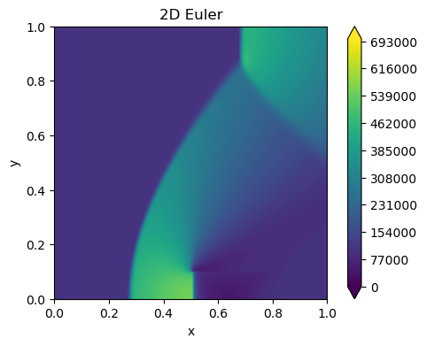

[figure not shown]

Once Loop Reflect

```python
# Animation setup
plt.close()
fig, ax = plt.subplots(figsize=(6.0,4.0))
c = ax.contourf(x, y, prims[-1][3,:,:].T, levels=np.linspace(0,7e5,101), extend='both')
ax.set_xlabel('x')
ax.set_ylabel('y')
ax.set_aspect('equal')
ax.set_title('2D Euler')
fig.colorbar(c)

def update(frame):
    ax.clear()
    c = ax.contourf(x, y, prims[frame][3,:,:].T, levels=np.linspace(0,7e5,101), extend='both')
    ax.set_title(f'2D Euler, Step {frame}')
    return c

anim = FuncAnimation(fig, update, frames=len(prims), blit=False, interval=50)

plt.show()
HTML(anim.to_jshtml())
```

Result discussed in part 2a.

# Part 2

## a.

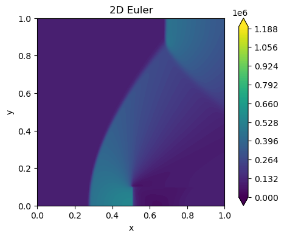

[figure not shown]

Once Loop Reflect

```python
# Animation setup
plt.close()
fig, ax = plt.subplots(figsize=(6.0,4.0))
c = ax.contourf(x, y, prims[-1][3,:,:].T, levels=np.linspace(0,1.2e6,101), extend='both')
ax.set_xlabel('x')
ax.set_ylabel('y')
ax.set_aspect('equal')
ax.set_title('2D Euler')
fig.colorbar(c)

def update(frame):
    ax.clear()
    c = ax.contourf(x, y, prims[frame][3,:,:].T, levels=np.linspace(0,1.2e6,101), extend='both')
    ax.set_title(f'2D Euler, Step {frame}')
    return c

anim = FuncAnimation(fig, update, frames=len(prims), blit=False, interval=50)

plt.show()
HTML(anim.to_jshtml())
```

We can see that a bow shock forms on the step. The shock forms far from the step and travels to the top of the domain where it reflects off of the top wall and travels back downwards. It also appears to coalesce into a normal shock that sits on the top wall. There is a low pressure zone through the expansion fan around the top corner of the step. Watching the animation shows the solution reach an unchanging steady state towards the end of the animation.

## b.

```python
# Parameters
gamma = 1.4      # Specific heat ratio
nx = 64         # Number of spatial points [x]
ny = 64         # Number of spatial points [y]
L_x = 1.0          # Length of domain
L_y = 1.0          # Length of domain
dx = L_x / (nx - 1)
dy = L_y / (ny - 1)
CFL = 0.5        # CFL number
tend = 4e-2       # Number of time steps

# Free-stream reference conditions
M_in = 2.0
rho_in = 1.2
pres_in = 1e5

# Setup the grid
x_ = np.linspace(0, L_x, nx)
y_ = np.linspace(0, L_y, ny)
x, y = np.meshgrid(x_,y_)

# Use the initial condition you want to use
# Here we will just set it to the freestream reference conditions
rho   = np.ones(x.shape)*rho_in
vel_x = np.ones(x.shape)*M_in * np.sqrt(gamma * pres_in / rho_in)
vel_y = np.ones(x.shape)*0.0
prs   = np.ones(x.shape)*pres_in
prim0 = np.array([rho, vel_x, vel_y, prs])

# Set initial conditions
cons0 = Prim2Cons(prim0[0,:,:], prim0[1,:,:], prim0[2,:,:], prim0[3,:,:])

# Initialize exact solution object
gamma = 1.4

# Set up the solution array u
cons = cons0.copy()
prim = prim0.copy()

# Store solution at each time step
prims = [prim.copy()]
conss = [cons.copy()]

# Save L2 norm errors in an array
errors = []

# Set locations for where we have the wall BC due to the step
i_wall = round(0.5*nx)
j_wmax = round(0.1*ny)

time = 0.0
time_write = 0.0
while(time < tend):
    # Find dt
    speed_sound = np.sqrt(gamma * prim[3,:,:] / prim[0,:,:])
    dt = CFL * dx / (np.max(np.sqrt(prim[1,:,:]**2 + prim[2,:,:]**2)+speed_sound))

    # Update time
    time = time + dt

    # Numerical solution update
    cons_new = cons.copy()
    prim_new = prim.copy()

    # Time-update (ADD YOUR CHANGES HERE)
    # Use NumPy arrays for fast impl
    cons_new[:,1:-1,1:-1] = cons[:,1:-1,1:-1] - dt*(\
            (HLLC_x(prim[0,1:-1,1:-1], prim[1,1:-1,1:-1], prim[2,1:-1,1:-1], prim[3,1:-1,1:-1], \
                    prim[0,1+1:,1:-1], prim[1,1+1:,1:-1], prim[2,1+1:,1:-1], prim[3,1+1:,1:-1]) - \
            HLLC_x(prim[0,1-1:-1-1,1:-1], prim[1,1-1:-1-1,1:-1], prim[2,1-1:-1-1,1:-1], prim[3,1-1:-1-1,1:-1], \
                    prim[0,1:-1,1:-1], prim[1,1:-1,1:-1], prim[2,1:-1,1:-1], prim[3,1:-1,1:-1]))/dx + \
            (HLLC_y(prim[0,1:-1,1:-1], prim[1,1:-1,1:-1], prim[2,1:-1,1:-1], prim[3,1:-1,1:-1], \
                    prim[0,1:-1,1+1:], prim[1,1:-1,1+1:], prim[2,1:-1,1+1:], prim[3,1:-1,1+1:]) - \
            HLLC_y(prim[0,1:-1,1-1:-1-1], prim[1,1:-1,1-1:-1-1], prim[2,1:-1,1-1:-1-1], prim[3,1:-1,1-1:-1-1], \
                    prim[0,1:-1,1:-1], prim[1,1:-1,1:-1], prim[2,1:-1,1:-1], prim[3,1:-1,1:-1]))/dy)

    # Update primitive variables from the new conservative variables
    cons = cons_new.copy()
    prim = Cons2Prim(cons[0,:,:], cons[1,:,:], cons[2,:,:], cons[3,:,:])

    # Update supersonic inflow on i=i_in
    # ADD YOUR CHANGES FOR BOUNDARY CONDITIONS
    i_in = 0
    prim[0,i_in,:] = prim0[0,i_in,:]
    prim[1,i_in,:] = prim0[1,i_in,:]
    prim[2,i_in,:] = prim0[2,i_in,:]
    prim[3,i_in,:] = prim0[3,i_in,:]

    # Update supersonic outflow on i=i_out
    i_out = -1
    prim[0,i_out,:] = prim[0,i_out-1,:]
    prim[1,i_out,:] = prim[1,i_out-1,:]
    prim[2,i_out,:] = prim[2,i_out-1,:]
    prim[3,i_out,:] = prim[3,i_out-1,:]

    # Update wall on j=j_wall (top)
    j_wall = -1
    prim[0,:,j_wall] = prim[0,:,j_wall-1]
    prim[1,:,j_wall] = prim[1,:,j_wall-1]
    prim[2,:,j_wall] = -prim[2,:,j_wall-1]
    prim[3,:,j_wall] = prim[3,:,j_wall-1]

    # Update wall on j=j_wall (bottom)
    j_wall = 0
    prim[0,:,j_wall] = prim[0,:,j_wall+1]
    prim[1,:,j_wall] = prim[1,:,j_wall+1]
    prim[2,:,j_wall] = -prim[2,:,j_wall+1]
    prim[3,:,j_wall] = prim[3,:,j_wall+1]

    # Update wall for step
    prim[0,i_wall,:j_wmax] = prim[0,i_wall-1,:j_wmax]
    prim[1,i_wall,:j_wmax] = -prim[1,i_wall-1,:j_wmax]
    prim[2,i_wall,:j_wmax] = prim[2,i_wall-1,:j_wmax]
    prim[3,i_wall,:j_wmax] = prim[3,i_wall-1,:j_wmax]

    prim[0,i_wall:,j_wmax] = prim[0,i_wall:,j_wmax+1]
    prim[1,i_wall:,j_wmax] = prim[1,i_wall:,j_wmax+1]
    prim[2,i_wall:,j_wmax] = -prim[2,i_wall:,j_wmax+1]
    prim[3,i_wall:,j_wmax] = prim[3,i_wall:,j_wmax+1]

    # Update conservatives back
    # We need to do this since we have updated the primitive variables
    # during the boundary condition update so we need to convert back
    # to conservatives
    cons = Prim2Cons(prim[0,:,:], prim[1,:,:], prim[2,:,:], prim[3,:,:])

    # Update the overall solution arrays
    # We will not do this every time step but every 1 ms
    if (time > time_write + 1e-3):
        time_write = time
        conss.append(cons.copy())
        prims.append(prim.copy())
```

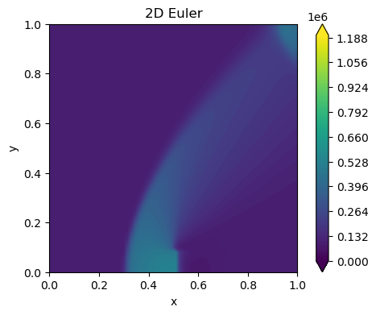

[figure not shown]

Once Loop Reflect

```python
# Animation setup
plt.close()
fig, ax = plt.subplots(figsize=(6.0,4.0))
c = ax.contourf(x, y, prims[-1][3,:,:].T, levels=np.linspace(0,1.2e6,101), extend='both')
ax.set_xlabel('x')
ax.set_ylabel('y')
ax.set_aspect('equal')
ax.set_title('2D Euler')
fig.colorbar(c)

def update(frame):
    ax.clear()
    c = ax.contourf(x, y, prims[frame][3,:,:].T, levels=np.linspace(0,1.2e6,101), extend='both')
    ax.set_title(f'2D Euler, Step {frame}')
    return c

anim = FuncAnimation(fig, update, frames=len(prims), blit=False, interval=50)

plt.show()
HTML(anim.to_jshtml())
```

The lower resolution grid shows a similar result. The bow shock forms and reflects off of the top wall. At the low resolution, however, much less of the reflection is visible. It does not form the same normal shock on the top wall and reflect far into the domain again like it does in the higher resolution case. It is clear that the solution is of a much lower resolution overall, but it retains most of the features seen in the original case.

## c.

```python
# Parameters
gamma = 1.4      # Specific heat ratio
nx = 256         # Number of spatial points [x]
ny = 256         # Number of spatial points [y]
L_x = 1.0          # Length of domain
L_y = 1.0          # Length of domain
dx = L_x / (nx - 1)
dy = L_y / (ny - 1)
CFL = 0.5        # CFL number
tend = 4e-2       # Number of time steps

# Free-stream reference conditions
M_in = 2.0
rho_in = 1.2
pres_in = 1e5

# Setup the grid
x_ = np.linspace(0, L_x, nx)
y_ = np.linspace(0, L_y, ny)
x, y = np.meshgrid(x_,y_)

# Use the initial condition you want to use
# Here we will just set it to the freestream reference conditions
rho   = np.ones(x.shape)*rho_in
vel_x = np.ones(x.shape)*M_in * np.sqrt(gamma * pres_in / rho_in)
vel_y = np.ones(x.shape)*0.0
prs   = np.ones(x.shape)*pres_in
prim0 = np.array([rho, vel_x, vel_y, prs])

# Set initial conditions
cons0 = Prim2Cons(prim0[0,:,:], prim0[1,:,:], prim0[2,:,:], prim0[3,:,:])

# Initialize exact solution object
gamma = 1.4

# Set up the solution array u
cons = cons0.copy()
prim = prim0.copy()

# Store solution at each time step
prims = [prim.copy()]
conss = [cons.copy()]

# Save L2 norm errors in an array
errors = []

# Set locations for where we have the wall BC due to the step
i_wall = round(0.5*nx)
j_wmax = round(0.1*ny)

time = 0.0
time_write = 0.0
while(time < tend):
    # Find dt
    speed_sound = np.sqrt(gamma * prim[3,:,:] / prim[0,:,:])
    dt = CFL * dx / (np.max(np.sqrt(prim[1,:,:]**2 + prim[2,:,:]**2)+speed_sound))

    # Update time
    time = time + dt

    # Numerical solution update
    cons_new = cons.copy()
    prim_new = prim.copy()

    # Time-update (ADD YOUR CHANGES HERE)
    # Use NumPy arrays for fast impl
    cons_new[:,1:-1,1:-1] = cons[:,1:-1,1:-1] - dt*(\
            (HLLC_x(prim[0,1:-1,1:-1], prim[1,1:-1,1:-1], prim[2,1:-1,1:-1], prim[3,1:-1,1:-1], \
                    prim[0,1+1:,1:-1], prim[1,1+1:,1:-1], prim[2,1+1:,1:-1], prim[3,1+1:,1:-1]) - \
            HLLC_x(prim[0,1-1:-1-1,1:-1], prim[1,1-1:-1-1,1:-1], prim[2,1-1:-1-1,1:-1], prim[3,1-1:-1-1,1:-1], \
                    prim[0,1:-1,1:-1], prim[1,1:-1,1:-1], prim[2,1:-1,1:-1], prim[3,1:-1,1:-1]))/dx + \
            (HLLC_y(prim[0,1:-1,1:-1], prim[1,1:-1,1:-1], prim[2,1:-1,1:-1], prim[3,1:-1,1:-1], \
                    prim[0,1:-1,1+1:], prim[1,1:-1,1+1:], prim[2,1:-1,1+1:], prim[3,1:-1,1+1:]) - \
            HLLC_y(prim[0,1:-1,1-1:-1-1], prim[1,1:-1,1-1:-1-1], prim[2,1:-1,1-1:-1-1], prim[3,1:-1,1-1:-1-1], \
                    prim[0,1:-1,1:-1], prim[1,1:-1,1:-1], prim[2,1:-1,1:-1], prim[3,1:-1,1:-1]))/dy)

    # Update primitive variables from the new conservative variables
    cons = cons_new.copy()
    prim = Cons2Prim(cons[0,:,:], cons[1,:,:], cons[2,:,:], cons[3,:,:])

    # Update supersonic inflow on i=i_in
    # ADD YOUR CHANGES FOR BOUNDARY CONDITIONS
    i_in = 0
    prim[0,i_in,:] = prim0[0,i_in,:]
    prim[1,i_in,:] = prim0[1,i_in,:]
    prim[2,i_in,:] = prim0[2,i_in,:]
    prim[3,i_in,:] = prim0[3,i_in,:]

    # Update supersonic outflow on i=i_out
    i_out = -1
    prim[0,i_out,:] = prim[0,i_out-1,:]
    prim[1,i_out,:] = prim[1,i_out-1,:]
    prim[2,i_out,:] = prim[2,i_out-1,:]
    prim[3,i_out,:] = prim[3,i_out-1,:]

    # Update wall on j=j_wall (top)
    j_wall = -1
    prim[0,:,j_wall] = prim[0,:,j_wall-1]
    prim[1,:,j_wall] = prim[1,:,j_wall-1]
    prim[2,:,j_wall] = -prim[2,:,j_wall-1]
    prim[3,:,j_wall] = prim[3,:,j_wall-1]

    # Update wall on j=j_wall (bottom)
    j_wall = 0
    prim[0,:,j_wall] = prim[0,:,j_wall+1]
    prim[1,:,j_wall] = prim[1,:,j_wall+1]
    prim[2,:,j_wall] = -prim[2,:,j_wall+1]
    prim[3,:,j_wall] = prim[3,:,j_wall+1]

    # Update wall for step
    prim[0,i_wall,:j_wmax] = prim[0,i_wall-1,:j_wmax]
    prim[1,i_wall,:j_wmax] = -prim[1,i_wall-1,:j_wmax]
    prim[2,i_wall,:j_wmax] = prim[2,i_wall-1,:j_wmax]
    prim[3,i_wall,:j_wmax] = prim[3,i_wall-1,:j_wmax]

    prim[0,i_wall:,j_wmax] = prim[0,i_wall:,j_wmax+1]
    prim[1,i_wall:,j_wmax] = prim[1,i_wall:,j_wmax+1]
    prim[2,i_wall:,j_wmax] = -prim[2,i_wall:,j_wmax+1]
    prim[3,i_wall:,j_wmax] = prim[3,i_wall:,j_wmax+1]

    # Update conservatives back
    # We need to do this since we have updated the primitive variables
    # during the boundary condition update so we need to convert back
    # to conservatives
    cons = Prim2Cons(prim[0,:,:], prim[1,:,:], prim[2,:,:], prim[3,:,:])

    # Update the overall solution arrays
    # We will not do this every time step but every 1 ms
    if (time > time_write + 1e-3):
        time_write = time
        conss.append(cons.copy())
        prims.append(prim.copy())
```

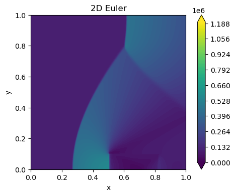

[figure not shown]

Once Loop Reflect

```python
# Animation setup
plt.close()
fig, ax = plt.subplots(figsize=(6.0,4.0))
c = ax.contourf(x, y, prims[-1][3,:,:].T, levels=np.linspace(0,1.2e6,101), extend='both')
ax.set_xlabel('x')
ax.set_ylabel('y')
ax.set_aspect('equal')
ax.set_title('2D Euler')
fig.colorbar(c)

def update(frame):
    ax.clear()
    c = ax.contourf(x, y, prims[frame][3,:,:].T, levels=np.linspace(0,1.2e6,101), extend='both')
    ax.set_title(f'2D Euler, Step {frame}')
    return c

anim = FuncAnimation(fig, update, frames=len(prims), blit=False, interval=50)

plt.show()
HTML(anim.to_jshtml())
```

We can see in the very high resolution grid that the shock interaction changes significantly. The same bow shock is generated on the front of the step and reflects back into the domain. Whereas the 128 grid formed a normal shock and the 64 grid did not, the high resolution forms a normal shock that starts to bend forwards towards the inlet and then reflects out the outlet. As we increase resolution, we are able to better resolve the interaction. This cell, however, took almost 10x as long to run as the 128-cell grid, so it comes at great computational cost.

## d.

```python
# Parameters
gamma = 1.4      # Specific heat ratio
nx = 128         # Number of spatial points [x]
ny = 128         # Number of spatial points [y]
L_x = 1.0          # Length of domain
L_y = 1.0          # Length of domain
dx = L_x / (nx - 1)
dy = L_y / (ny - 1)
CFL = 0.5        # CFL number
tend = 4e-2       # Number of time steps

# Free-stream reference conditions
M_in = 2.5
rho_in = 1.2
pres_in = 1e5

# Setup the grid
x_ = np.linspace(0, L_x, nx)
y_ = np.linspace(0, L_y, ny)
x, y = np.meshgrid(x_,y_)

# Use the initial condition you want to use
# Here we will just set it to the freestream reference conditions
rho   = np.ones(x.shape)*rho_in
vel_x = np.ones(x.shape)*M_in * np.sqrt(gamma * pres_in / rho_in)
vel_y = np.ones(x.shape)*0.0
prs   = np.ones(x.shape)*pres_in
prim0 = np.array([rho, vel_x, vel_y, prs])

# Set initial conditions
cons0 = Prim2Cons(prim0[0,:,:], prim0[1,:,:], prim0[2,:,:], prim0[3,:,:])

# Initialize exact solution object
gamma = 1.4

# Set up the solution array u
cons = cons0.copy()
prim = prim0.copy()

# Store solution at each time step
prims = [prim.copy()]
conss = [cons.copy()]

# Save L2 norm errors in an array
errors = []

# Set locations for where we have the wall BC due to the step
i_wall = round(0.5*nx)
j_wmax = round(0.1*ny)

time = 0.0
time_write = 0.0
while(time < tend):
    # Find dt
    speed_sound = np.sqrt(gamma * prim[3,:,:] / prim[0,:,:])
    dt = CFL * dx / (np.max(np.sqrt(prim[1,:,:]**2 + prim[2,:,:]**2)+speed_sound))

    # Update time
    time = time + dt

    # Numerical solution update
    cons_new = cons.copy()
    prim_new = prim.copy()

    # Time-update (ADD YOUR CHANGES HERE)
    # Use NumPy arrays for fast impl
    cons_new[:,1:-1,1:-1] = cons[:,1:-1,1:-1] - dt*(\
            (HLLC_x(prim[0,1:-1,1:-1], prim[1,1:-1,1:-1], prim[2,1:-1,1:-1], prim[3,1:-1,1:-1], \
                    prim[0,1+1:,1:-1], prim[1,1+1:,1:-1], prim[2,1+1:,1:-1], prim[3,1+1:,1:-1]) - \
            HLLC_x(prim[0,1-1:-1-1,1:-1], prim[1,1-1:-1-1,1:-1], prim[2,1-1:-1-1,1:-1], prim[3,1-1:-1-1,1:-1], \
                    prim[0,1:-1,1:-1], prim[1,1:-1,1:-1], prim[2,1:-1,1:-1], prim[3,1:-1,1:-1]))/dx + \
            (HLLC_y(prim[0,1:-1,1:-1], prim[1,1:-1,1:-1], prim[2,1:-1,1:-1], prim[3,1:-1,1:-1], \
                    prim[0,1:-1,1+1:], prim[1,1:-1,1+1:], prim[2,1:-1,1+1:], prim[3,1:-1,1+1:]) - \
            HLLC_y(prim[0,1:-1,1-1:-1-1], prim[1,1:-1,1-1:-1-1], prim[2,1:-1,1-1:-1-1], prim[3,1:-1,1-1:-1-1], \
                    prim[0,1:-1,1:-1], prim[1,1:-1,1:-1], prim[2,1:-1,1:-1], prim[3,1:-1,1:-1]))/dy)

    # Update primitive variables from the new conservative variables
    cons = cons_new.copy()
    prim = Cons2Prim(cons[0,:,:], cons[1,:,:], cons[2,:,:], cons[3,:,:])

    # Update supersonic inflow on i=i_in
    # ADD YOUR CHANGES FOR BOUNDARY CONDITIONS
    i_in = 0
    prim[0,i_in,:] = prim0[0,i_in,:]
    prim[1,i_in,:] = prim0[1,i_in,:]
    prim[2,i_in,:] = prim0[2,i_in,:]
    prim[3,i_in,:] = prim0[3,i_in,:]

    # Update supersonic outflow on i=i_out
    i_out = -1
    prim[0,i_out,:] = prim[0,i_out-1,:]
    prim[1,i_out,:] = prim[1,i_out-1,:]
    prim[2,i_out,:] = prim[2,i_out-1,:]
    prim[3,i_out,:] = prim[3,i_out-1,:]

    # Update wall on j=j_wall (top)
    j_wall = -1
    prim[0,:,j_wall] = prim[0,:,j_wall-1]
    prim[1,:,j_wall] = prim[1,:,j_wall-1]
    prim[2,:,j_wall] = -prim[2,:,j_wall-1]
    prim[3,:,j_wall] = prim[3,:,j_wall-1]

    # Update wall on j=j_wall (bottom)
    j_wall = 0
    prim[0,:,j_wall] = prim[0,:,j_wall+1]
    prim[1,:,j_wall] = prim[1,:,j_wall+1]
    prim[2,:,j_wall] = -prim[2,:,j_wall+1]
    prim[3,:,j_wall] = prim[3,:,j_wall+1]

    # Update wall for step
    prim[0,i_wall,:j_wmax] = prim[0,i_wall-1,:j_wmax]
    prim[1,i_wall,:j_wmax] = -prim[1,i_wall-1,:j_wmax]
    prim[2,i_wall,:j_wmax] = prim[2,i_wall-1,:j_wmax]
    prim[3,i_wall,:j_wmax] = prim[3,i_wall-1,:j_wmax]

    prim[0,i_wall:,j_wmax] = prim[0,i_wall:,j_wmax+1]
    prim[1,i_wall:,j_wmax] = prim[1,i_wall:,j_wmax+1]
    prim[2,i_wall:,j_wmax] = -prim[2,i_wall:,j_wmax+1]
    prim[3,i_wall:,j_wmax] = prim[3,i_wall:,j_wmax+1]

    # Update conservatives back
    # We need to do this since we have updated the primitive variables
    # during the boundary condition update so we need to convert back
    # to conservatives
    cons = Prim2Cons(prim[0,:,:], prim[1,:,:], prim[2,:,:], prim[3,:,:])

    # Update the overall solution arrays
    # We will not do this every time step but every 1 ms
    if (time > time_write + 1e-3):
        time_write = time
        conss.append(cons.copy())
        prims.append(prim.copy())
```

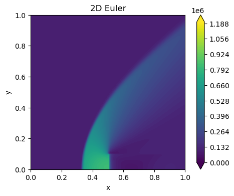

[figure not shown]

Once Loop Reflect

```python
# Animation setup
plt.close()
fig, ax = plt.subplots(figsize=(6.0,4.0))
c = ax.contourf(x, y, prims[-1][3,:,:].T, levels=np.linspace(0,1.2e6,101), extend='both')
ax.set_xlabel('x')
ax.set_ylabel('y')
ax.set_aspect('equal')
ax.set_title('2D Euler')
fig.colorbar(c)

def update(frame):
    ax.clear()
    c = ax.contourf(x, y, prims[frame][3,:,:].T, levels=np.linspace(0,1.2e6,101), extend='both')
    ax.set_title(f'2D Euler, Step {frame}')
    return c

anim = FuncAnimation(fig, update, frames=len(prims), blit=False, interval=50)

plt.show()
HTML(anim.to_jshtml())
```

We can see for an inflow speed of Mach 2.5, the solution is fairly similar. A bow shock forms far in front of the step and travels up towards the top of the domain. Unlike previous solutions, the shock does not reflect but instead travels out of the domain to the right. The pressure on the front of the step is a little bit higher than that seen previously.

## e.

```python
# Parameters
gamma = 1.4      # Specific heat ratio
nx = 128         # Number of spatial points [x]
ny = 128         # Number of spatial points [y]
L_x = 1.0          # Length of domain
L_y = 1.0          # Length of domain
dx = L_x / (nx - 1)
dy = L_y / (ny - 1)
CFL = 0.5        # CFL number
tend = 4e-2       # Number of time steps

# Free-stream reference conditions
M_in = 3.0
rho_in = 1.2
pres_in = 1e5

# Setup the grid
x_ = np.linspace(0, L_x, nx)
y_ = np.linspace(0, L_y, ny)
x, y = np.meshgrid(x_,y_)

# Use the initial condition you want to use
# Here we will just set it to the freestream reference conditions
rho   = np.ones(x.shape)*rho_in
vel_x = np.ones(x.shape)*M_in * np.sqrt(gamma * pres_in / rho_in)
vel_y = np.ones(x.shape)*0.0
prs   = np.ones(x.shape)*pres_in
prim0 = np.array([rho, vel_x, vel_y, prs])

# Set initial conditions
cons0 = Prim2Cons(prim0[0,:,:], prim0[1,:,:], prim0[2,:,:], prim0[3,:,:])

# Initialize exact solution object
gamma = 1.4

# Set up the solution array u
cons = cons0.copy()
prim = prim0.copy()

# Store solution at each time step
prims = [prim.copy()]
conss = [cons.copy()]

# Save L2 norm errors in an array
errors = []

# Set locations for where we have the wall BC due to the step
i_wall = round(0.5*nx)
j_wmax = round(0.1*ny)

time = 0.0
time_write = 0.0
while(time < tend):
    # Find dt
    speed_sound = np.sqrt(gamma * prim[3,:,:] / prim[0,:,:])
    dt = CFL * dx / (np.max(np.sqrt(prim[1,:,:]**2 + prim[2,:,:]**2)+speed_sound))

    # Update time
    time = time + dt

    # Numerical solution update
    cons_new = cons.copy()
    prim_new = prim.copy()

    # Time-update (ADD YOUR CHANGES HERE)
    # Use NumPy arrays for fast impl
    cons_new[:,1:-1,1:-1] = cons[:,1:-1,1:-1] - dt*(\
            (HLLC_x(prim[0,1:-1,1:-1], prim[1,1:-1,1:-1], prim[2,1:-1,1:-1], prim[3,1:-1,1:-1], \
                    prim[0,1+1:,1:-1], prim[1,1+1:,1:-1], prim[2,1+1:,1:-1], prim[3,1+1:,1:-1]) - \
            HLLC_x(prim[0,1-1:-1-1,1:-1], prim[1,1-1:-1-1,1:-1], prim[2,1-1:-1-1,1:-1], prim[3,1-1:-1-1,1:-1], \
                    prim[0,1:-1,1:-1], prim[1,1:-1,1:-1], prim[2,1:-1,1:-1], prim[3,1:-1,1:-1]))/dx + \
            (HLLC_y(prim[0,1:-1,1:-1], prim[1,1:-1,1:-1], prim[2,1:-1,1:-1], prim[3,1:-1,1:-1], \
                    prim[0,1:-1,1+1:], prim[1,1:-1,1+1:], prim[2,1:-1,1+1:], prim[3,1:-1,1+1:]) - \
            HLLC_y(prim[0,1:-1,1-1:-1-1], prim[1,1:-1,1-1:-1-1], prim[2,1:-1,1-1:-1-1], prim[3,1:-1,1-1:-1-1], \
                    prim[0,1:-1,1:-1], prim[1,1:-1,1:-1], prim[2,1:-1,1:-1], prim[3,1:-1,1:-1]))/dy)

    # Update primitive variables from the new conservative variables
    cons = cons_new.copy()
    prim = Cons2Prim(cons[0,:,:], cons[1,:,:], cons[2,:,:], cons[3,:,:])

    # Update supersonic inflow on i=i_in
    # ADD YOUR CHANGES FOR BOUNDARY CONDITIONS
    i_in = 0
    prim[0,i_in,:] = prim0[0,i_in,:]
    prim[1,i_in,:] = prim0[1,i_in,:]
    prim[2,i_in,:] = prim0[2,i_in,:]
    prim[3,i_in,:] = prim0[3,i_in,:]

    # Update supersonic outflow on i=i_out
    i_out = -1
    prim[0,i_out,:] = prim[0,i_out-1,:]
    prim[1,i_out,:] = prim[1,i_out-1,:]
    prim[2,i_out,:] = prim[2,i_out-1,:]
    prim[3,i_out,:] = prim[3,i_out-1,:]

    # Update wall on j=j_wall (top)
    j_wall = -1
    prim[0,:,j_wall] = prim[0,:,j_wall-1]
    prim[1,:,j_wall] = prim[1,:,j_wall-1]
    prim[2,:,j_wall] = -prim[2,:,j_wall-1]
    prim[3,:,j_wall] = prim[3,:,j_wall-1]

    # Update wall on j=j_wall (bottom)
    j_wall = 0
    prim[0,:,j_wall] = prim[0,:,j_wall+1]
    prim[1,:,j_wall] = prim[1,:,j_wall+1]
    prim[2,:,j_wall] = -prim[2,:,j_wall+1]
    prim[3,:,j_wall] = prim[3,:,j_wall+1]

    # Update wall for step
    prim[0,i_wall,:j_wmax] = prim[0,i_wall-1,:j_wmax]
    prim[1,i_wall,:j_wmax] = -prim[1,i_wall-1,:j_wmax]
    prim[2,i_wall,:j_wmax] = prim[2,i_wall-1,:j_wmax]
    prim[3,i_wall,:j_wmax] = prim[3,i_wall-1,:j_wmax]

    prim[0,i_wall:,j_wmax] = prim[0,i_wall:,j_wmax+1]
    prim[1,i_wall:,j_wmax] = prim[1,i_wall:,j_wmax+1]
    prim[2,i_wall:,j_wmax] = -prim[2,i_wall:,j_wmax+1]
    prim[3,i_wall:,j_wmax] = prim[3,i_wall:,j_wmax+1]

    # Update conservatives back
    # We need to do this since we have updated the primitive variables
    # during the boundary condition update so we need to convert back
    # to conservatives
    cons = Prim2Cons(prim[0,:,:], prim[1,:,:], prim[2,:,:], prim[3,:,:])

    # Update the overall solution arrays
    # We will not do this every time step but every 1 ms
    if (time > time_write + 1e-3):
        time_write = time
        conss.append(cons.copy())
        prims.append(prim.copy())
```

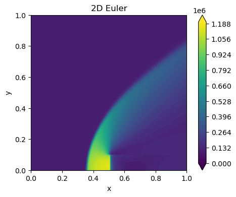

[figure not shown]

Once Loop Reflect

```python
# Animation setup
plt.close()
fig, ax = plt.subplots(figsize=(6.0,4.0))
c = ax.contourf(x, y, prims[-1][3,:,:].T, levels=np.linspace(0,1.2e6,101), extend='both')
ax.set_xlabel('x')
ax.set_ylabel('y')
ax.set_aspect('equal')
ax.set_title('2D Euler')
fig.colorbar(c)

def update(frame):
    ax.clear()
    c = ax.contourf(x, y, prims[frame][3,:,:].T, levels=np.linspace(0,1.2e6,101), extend='both')
    ax.set_title(f'2D Euler, Step {frame}')
    return c

anim = FuncAnimation(fig, update, frames=len(prims), blit=False, interval=50)

plt.show()
HTML(anim.to_jshtml())
```

The highest speed case shows an even stronger bow shock in a similar location to the other results. The pressure on the front of the step is very high and the bow shock turns and travels out of the domain to the right without getting close to the top wall.